# 1. Préparation des données

## Chargement des données

Le fichier contenant les Q-values est chargé puis la première colonne, correspondant à l’identifiant des individus, est utilisée comme nom de ligne.

```r
path <- "/Users/andregilles/Desktop/Desktop/programme recherche/Etudiant_es/Jef_article/hybride"

setwd(path)

data <- read.csv2(
  "genome_hotox.csv",
  header = TRUE,
  dec = ",",
  check.names = FALSE
)

head(data)
```

```
##      Individu   Q2_Ch1    Q2_Ch2   Q2_ch3   Q1_ch4    Q2_ch5     Q2_ch6
## 1 14Ain1001Cn 0.999643 0.9677080 0.970028 0.999900 0.9999000 0.99664000
## 2 14Ain1002Cn 0.965227 0.9999000 0.995048 0.999900 0.9999000 0.98661800
## 3 14Ain1012Pt 0.000100 0.0001000 0.000100 0.000100 0.0322528 0.00994482
## 4 14Ain1013Pt 0.000100 0.0001000 0.000100 0.000100 0.0001000 0.00010000
## 5 14Ain1014Pt 0.000100 0.0173041 0.000100 0.000100 0.0194883 0.00010000
## 6 14Ain1036Cn 0.965587 0.9311710 0.924312 0.964978 0.9368630 0.99990000
##      Q2_ch7    Q1_ch8    Q2_Ch9  Q1_Ch10    Q2_ch11   Q2_Ch12 Q2_ch13  Q1_14
## 1 0.9999000 0.9999000 0.9866660 0.999900 0.99990000 0.9999000  0.9999 0.9999
## 2 0.9999000 0.9999000 0.9999000 0.999900 0.99990000 0.9999000  0.9999 0.9999
## 3 0.0341256 0.0001000 0.0001000 0.000100 0.00010000 0.0118634  0.0001 0.0001
## 4 0.0001000 0.0001000 0.0001000 0.000100 0.00010000 0.0001000  0.0001 0.0001
## 5 0.0001000 0.0154818 0.0143011 0.000100 0.00507816 0.0001000  0.0001 0.0001
## 6 0.9508660 0.9294650 0.9801190 0.977875 0.97208700 0.9598250  0.9999 0.9999
##        Q2_15    Q2_16       Q1_17   Q2_Ch18  Q1_ch19  Q2_ch20    Q1_ch21
## 1 0.99990000 0.999900 0.999900000 0.9816900 0.982930 0.984988 0.99990000
## 2 0.99990000 0.999900 0.999900000 0.9999000 0.999900 0.983091 0.99990000
## 3 0.00010000 0.000100 0.009234600 0.0001000 0.000100 0.000100 0.00010000
## 4 0.00383158 0.000100 0.000893825 0.0100728 0.000100 0.000100 0.00136594
## 5 0.02763820 0.000100 0.020020200 0.0001000 0.004375 0.000100 0.00010000
## 6 0.98169300 0.992472 0.948606000 0.9999000 0.956807 0.999900 0.98056800
##    Q1_ch22  Q1_ch23    Q2_24  Q2_ch25
## 1 0.999900 0.999900 0.999900 0.999900
## 2 0.972823 0.999900 0.986852 0.999900
## 3 0.000100 0.000100 0.000100 0.000100
## 4 0.000100 0.000100 0.000100 0.000100
## 5 0.000100 0.000100 0.000100 0.000100
## 6 0.967016 0.997708 0.907572 0.944228
```

```r
str(data)
```

```
## 'data.frame':    175 obs. of  26 variables:
##  $ Individu: chr  "14Ain1001Cn" "14Ain1002Cn" "14Ain1012Pt" "14Ain1013Pt" ...
##  $ Q2_Ch1  : num  0.9996 0.9652 0.0001 0.0001 0.0001 ...
##  $ Q2_Ch2  : num  0.9677 0.9999 0.0001 0.0001 0.0173 ...
##  $ Q2_ch3  : num  0.97 0.995 0.0001 0.0001 0.0001 ...
##  $ Q1_ch4  : num  1e+00 1e+00 1e-04 1e-04 1e-04 ...
##  $ Q2_ch5  : num  0.9999 0.9999 0.0323 0.0001 0.0195 ...
##  $ Q2_ch6  : num  0.99664 0.98662 0.00994 0.0001 0.0001 ...
##  $ Q2_ch7  : num  0.9999 0.9999 0.0341 0.0001 0.0001 ...
##  $ Q1_ch8  : num  0.9999 0.9999 0.0001 0.0001 0.0155 ...
##  $ Q2_Ch9  : num  0.9867 0.9999 0.0001 0.0001 0.0143 ...
##  $ Q1_Ch10 : num  1e+00 1e+00 1e-04 1e-04 1e-04 ...
##  $ Q2_ch11 : num  0.9999 0.9999 0.0001 0.0001 0.00508 ...
##  $ Q2_Ch12 : num  0.9999 0.9999 0.0119 0.0001 0.0001 ...
##  $ Q2_ch13 : num  1e+00 1e+00 1e-04 1e-04 1e-04 ...
##  $ Q1_14   : num  1e+00 1e+00 1e-04 1e-04 1e-04 ...
##  $ Q2_15   : num  0.9999 0.9999 0.0001 0.00383 0.02764 ...
##  $ Q2_16   : num  1e+00 1e+00 1e-04 1e-04 1e-04 ...
##  $ Q1_17   : num  0.9999 0.9999 0.009235 0.000894 0.02002 ...
##  $ Q2_Ch18 : num  0.9817 0.9999 0.0001 0.0101 0.0001 ...
##  $ Q1_ch19 : num  0.98293 0.9999 0.0001 0.0001 0.00438 ...
##  $ Q2_ch20 : num  0.985 0.9831 0.0001 0.0001 0.0001 ...
##  $ Q1_ch21 : num  0.9999 0.9999 0.0001 0.00137 0.0001 ...
##  $ Q1_ch22 : num  0.9999 0.9728 0.0001 0.0001 0.0001 ...
##  $ Q1_ch23 : num  1e+00 1e+00 1e-04 1e-04 1e-04 ...
##  $ Q2_24   : num  0.9999 0.9869 0.0001 0.0001 0.0001 ...
##  $ Q2_ch25 : num  1e+00 1e+00 1e-04 1e-04 1e-04 ...
```

## Construction de la matrice de Q-values

```r
mat <- data[, -1]

rownames(mat) <- data$Individu

head(mat)
```

```
##               Q2_Ch1    Q2_Ch2   Q2_ch3   Q1_ch4    Q2_ch5     Q2_ch6    Q2_ch7
## 14Ain1001Cn 0.999643 0.9677080 0.970028 0.999900 0.9999000 0.99664000 0.9999000
## 14Ain1002Cn 0.965227 0.9999000 0.995048 0.999900 0.9999000 0.98661800 0.9999000
## 14Ain1012Pt 0.000100 0.0001000 0.000100 0.000100 0.0322528 0.00994482 0.0341256
## 14Ain1013Pt 0.000100 0.0001000 0.000100 0.000100 0.0001000 0.00010000 0.0001000
## 14Ain1014Pt 0.000100 0.0173041 0.000100 0.000100 0.0194883 0.00010000 0.0001000
## 14Ain1036Cn 0.965587 0.9311710 0.924312 0.964978 0.9368630 0.99990000 0.9508660
##                Q1_ch8    Q2_Ch9  Q1_Ch10    Q2_ch11   Q2_Ch12 Q2_ch13  Q1_14
## 14Ain1001Cn 0.9999000 0.9866660 0.999900 0.99990000 0.9999000  0.9999 0.9999
## 14Ain1002Cn 0.9999000 0.9999000 0.999900 0.99990000 0.9999000  0.9999 0.9999
## 14Ain1012Pt 0.0001000 0.0001000 0.000100 0.00010000 0.0118634  0.0001 0.0001
## 14Ain1013Pt 0.0001000 0.0001000 0.000100 0.00010000 0.0001000  0.0001 0.0001
## 14Ain1014Pt 0.0154818 0.0143011 0.000100 0.00507816 0.0001000  0.0001 0.0001
## 14Ain1036Cn 0.9294650 0.9801190 0.977875 0.97208700 0.9598250  0.9999 0.9999
##                  Q2_15    Q2_16       Q1_17   Q2_Ch18  Q1_ch19  Q2_ch20
## 14Ain1001Cn 0.99990000 0.999900 0.999900000 0.9816900 0.982930 0.984988
## 14Ain1002Cn 0.99990000 0.999900 0.999900000 0.9999000 0.999900 0.983091
## 14Ain1012Pt 0.00010000 0.000100 0.009234600 0.0001000 0.000100 0.000100
## 14Ain1013Pt 0.00383158 0.000100 0.000893825 0.0100728 0.000100 0.000100
## 14Ain1014Pt 0.02763820 0.000100 0.020020200 0.0001000 0.004375 0.000100
## 14Ain1036Cn 0.98169300 0.992472 0.948606000 0.9999000 0.956807 0.999900
##                Q1_ch21  Q1_ch22  Q1_ch23    Q2_24  Q2_ch25
## 14Ain1001Cn 0.99990000 0.999900 0.999900 0.999900 0.999900
## 14Ain1002Cn 0.99990000 0.972823 0.999900 0.986852 0.999900
## 14Ain1012Pt 0.00010000 0.000100 0.000100 0.000100 0.000100
## 14Ain1013Pt 0.00136594 0.000100 0.000100 0.000100 0.000100
## 14Ain1014Pt 0.00010000 0.000100 0.000100 0.000100 0.000100
## 14Ain1036Cn 0.98056800 0.967016 0.997708 0.907572 0.944228
```

# 2. Clustering hiérarchique

Le clustering est réalisé à partir des profils de Q-values des individus.

La distance euclidienne mesure la différence entre les profils, puis la méthode de Ward (`ward.D2`) permet de construire le dendrogramme.

```r
dist_mat <- dist(mat, method = "euclidean")

hc <- hclust(
  dist_mat,
  method = "ward.D2"
)
```

## Choix du nombre de clusters

La largeur moyenne de silhouette est calculée pour différents nombres de clusters, de 2 à 15.

```r
silhouette_moyenne <- numeric(15)

for (k in 2:15) {

  groups_k <- cutree(hc, k = k)

  sil <- silhouette(
    groups_k,
    dist_mat
  )

  silhouette_moyenne[k] <- mean(sil[, 3])
}
```

### Largeur moyenne de silhouette

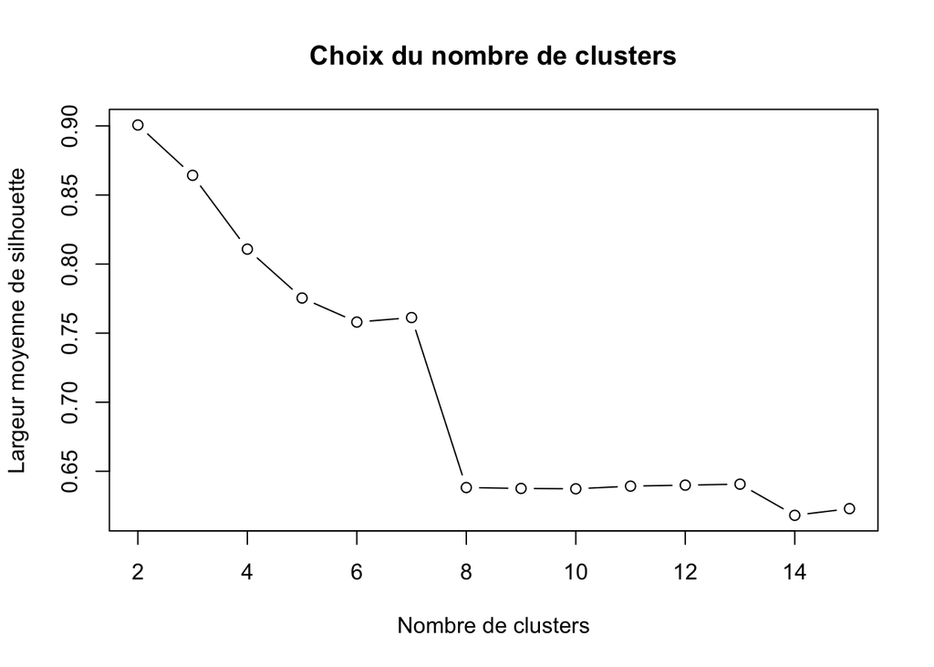

```r
plot(
  2:15,
  silhouette_moyenne[2:15],
  type = "b",
  xlab = "Nombre de clusters",
  ylab = "Largeur moyenne de silhouette",
  main = "Choix du nombre de clusters"
)
```

## Dendrogramme 7

```r
groups <- cutree(hc, k = 7)

table(groups)
```

```
## groups
##  1  2  3  4  5  6  7
## 67 88  9  3  4  1  3
```

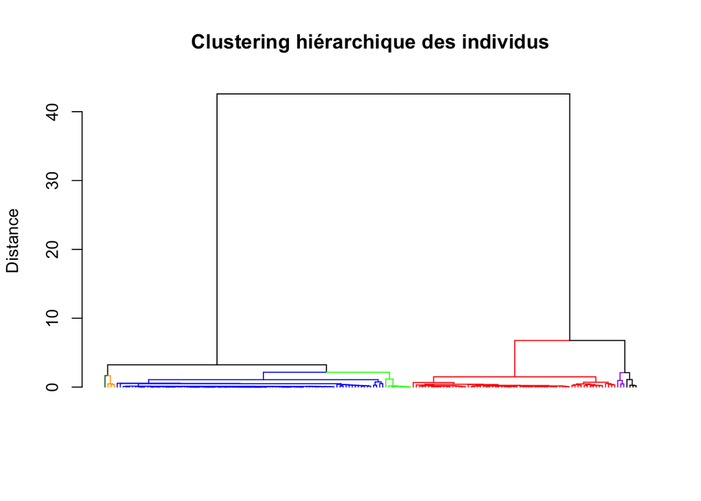

```r
dend <- as.dendrogram(hc)

dend <- color_branches(dend, k = 7,  col = c("darkgreen","orange","blue","green",  "red", "purple", "black"))

plot(
  dend,
  main = "Clustering hiérarchique des individus",
  ylab = "Distance",
  leaflab = "none"
)
```

## Dendrogramme 8

```r
groups <- cutree(hc, k = 8)

table(groups)
```

```
## groups
##  1  2  3  4  5  6  7  8
## 52 88 15  9  3  4  1  3
```

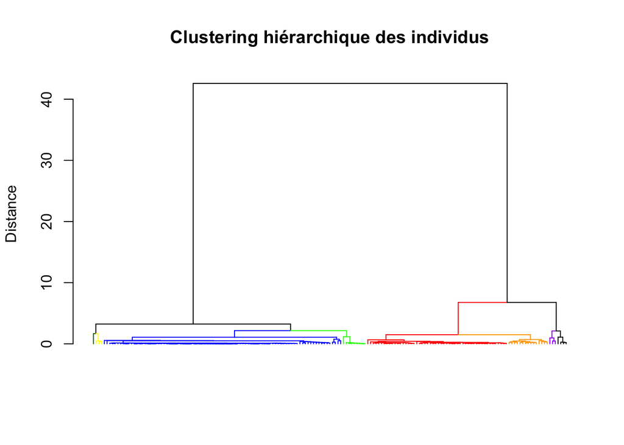

```r
dend <- color_branches(dend, k = 8,  col = c("darkgreen","yellow","blue","green",  "red", "orange","purple", "black"))

plot(dend,
     main = "Clustering hiérarchique des individus",
     ylab = "Distance",
     leaflab = "none")
```

# 3. Heatmap des Q-values

La heatmap permet de visualiser les profils de Q-values des différents individus.

L’échelle est fixée entre 0 et 1, indépendamment des valeurs effectivement présentes dans les données.

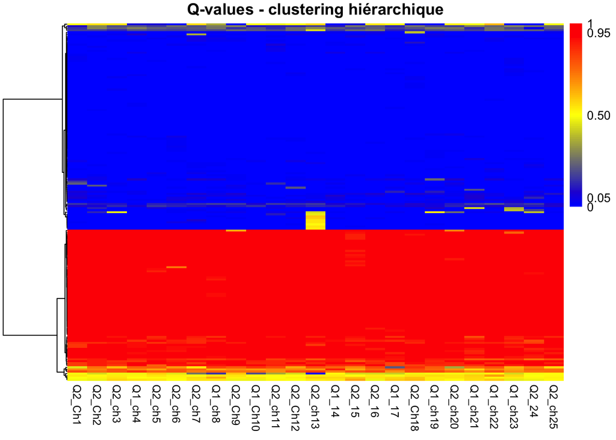

```r
col_fun <- colorRampPalette(
  c("blue", "yellow", "red")
)(100)

breaks <- seq(
  0,
  1,
  length.out = 101
)

pheatmap(
  mat,
  cluster_rows = hc,
  cluster_cols = FALSE,
  color = col_fun,
  breaks = breaks,
  show_rownames = FALSE,
  show_colnames = TRUE,
  fontsize_col = 9,
  border_color = NA,
  main = "Q-values - clustering hiérarchique",
  legend_breaks = c(0, 0.05, 0.5, 0.95, 1),
  legend_labels = c("0", "0.05", "0.50", "0.95", "1")
)
```

# 4. Indice hybride : médiane et écart maximal

Pour chaque individu, deux paramètres sont calculés :

- la **médiane des Q-values** ;
- l’**écart maximal à la médiane**.

L’écart maximal correspond à la plus grande différence entre la médiane et la valeur minimale ou maximale observée.

## Calcul de la médiane

```r
mediane <- apply(
  mat,
  1,
  median,
  na.rm = TRUE
)
```

## Calcul de l’écart maximal

```r
ecart_max <- apply(
  mat,
  1,
  function(x) {

    med <- median(
      x,
      na.rm = TRUE
    )

    max(
      max(x, na.rm = TRUE) - med,
      med - min(x, na.rm = TRUE)
    )
  }
)
```

## Tableau récapitulatif

```r
resultats <- data.frame(
  Individu = rownames(mat),
  Mediane = mediane,
  Ecart_max = ecart_max,
  Cluster = factor(groups)
)

resultats
```

```
##                Individu     Mediane  Ecart_max Cluster
## 14Ain1001Cn 14Ain1001Cn 0.999900000 0.03219200       1
## 14Ain1002Cn 14Ain1002Cn 0.999900000 0.03467300       1
## 14Ain1012Pt 14Ain1012Pt 0.000100000 0.03402560       2
## 14Ain1013Pt 14Ain1013Pt 0.000100000 0.00997280       2
## 14Ain1014Pt 14Ain1014Pt 0.000100000 0.02753820       2
## 14Ain1036Cn 14Ain1036Cn 0.967016000 0.05944400       3
## 14Ain1042Pt 14Ain1042Pt 0.000100000 0.02527610       2
## 14Ain1043Pt 14Ain1043Pt 0.000100000 0.00638026       2
## 14Ain1011Pt 14Ain1011Pt 0.000100000 0.02981160       2
## 14Ain1037Cn 14Ain1037Cn 0.999900000 0.05041800       1
## 14Ain1038Pt 14Ain1038Pt 0.000100000 0.01056080       2
## 14Ain1039Pt 14Ain1039Pt 0.000100000 0.01429520       2
## 14Ain1040Pt 14Ain1040Pt 0.000100000 0.02934460       2
## 14Ain1041Pt 14Ain1041Pt 0.000100000 0.00425925       2
## 14Avi1001Cn 14Avi1001Cn 0.999900000 0.04434400       1
## 14Avi1002Cn 14Avi1002Cn 0.999900000 0.02603300       1
## 14Avi1003Cn 14Avi1003Cn 0.999900000 0.08229200       1
## 14Avi1004Cn 14Avi1004Cn 0.999900000 0.04953200       1
## 14Avi1005Cn 14Avi1005Cn 0.999900000 0.08110800       1
## 14Avi1006Cn 14Avi1006Cn 0.999900000 0.06947300       1
## 14Avi1007Cn 14Avi1007Cn 0.999900000 0.05286700       1
## 14Avi1008Cn 14Avi1008Cn 0.980049000 0.06918900       1
## 14Avi1036Cn 14Avi1036Cn 0.999900000 0.02518200       1
## 14Avi1037Cn 14Avi1037Cn 0.999900000 0.11406600       1
## 14Avi1038Cn 14Avi1038Cn 0.999900000 0.03108800       1
## 14Bue1003Cn 14Bue1003Cn 0.999724000 0.07858800       1
## 14Bue1004Cn 14Bue1004Cn 0.999900000 0.08070200       1
## 14Bue1005Cn 14Bue1005Cn 0.999900000 0.08989400       1
## 14Bue1006Hy 14Bue1006Hy 0.910415000 0.13014100       3
## 14Bue1013Pt 14Bue1013Pt 0.000100000 0.02338930       2
## 14Bue1014Pt 14Bue1014Pt 0.000100000 0.02325980       2
## 14Bue1015Pt 14Bue1015Pt 0.000100000 0.02720600       2
## 14Bue1016Hy 14Bue1016Hy 0.000100000 0.54848600       4
## 14Bue1017Pt 14Bue1017Pt 0.000100000 0.04616090       2
## 14Bue1007Cn 14Bue1007Cn 0.999900000 0.05134200       1
## 14Bue1008Cn 14Bue1008Cn 0.999900000 0.08782500       1
## 14Bue1011Pt 14Bue1011Pt 0.000100000 0.02321610       2
## 14Bue1012Pt 14Bue1012Pt 0.000100000 0.00528295       2
## 14Bue1018Pt 14Bue1018Pt 0.000100000 0.00955994       2
```

[output cut: 121 more lines]

```
## 15Jus1014Cn 15Jus1014Cn 0.948472000 0.07077100       3
## 15Jus1001Pt 15Jus1001Pt 0.000100000 0.00000000       2
## 15Jus1002Hy 15Jus1002Hy 0.000100000 0.58527300       4
## 15Jus1003Hy 15Jus1003Hy 0.029490500 0.21727250       2
## 15Jus1006Pt 15Jus1006Pt 0.000100000 0.02119630       2
## 15Jus1007Pt 15Jus1007Pt 0.000100000 0.01419900       2
## 15Jus1009Hy 15Jus1009Hy 0.471594000 0.47149400       6
## 15Jus1010Cn 15Jus1010Cn 0.999900000 0.10209400       1
## 15Jus1011Cn 15Jus1011Cn 0.960241000 0.08472500       3
## 15Jus1012Cn 15Jus1012Cn 0.999900000 0.10607500       1
## 15Jus1015Cn 15Jus1015Cn 0.999900000 0.10453000       1
## 15Jus1016Hy 15Jus1016Hy 0.999900000 0.23044900       1
## 15Jus1017Cn 15Jus1017Cn 0.999900000 0.09948700       1
## 15Jus1018Cn 15Jus1018Cn 0.999900000 0.05409800       1
## 15Jus1019Cn 15Jus1019Cn 0.999900000 0.05579000       1
```

# 5. Classification des individus

Les individus sont ensuite classés selon leur médiane et leur écart maximal.

## Initialisation

```r
resultats$Groupe <- "Autres"
```

## Groupe Rouge

Médiane inférieure à 0.05 et écart maximal inférieur à 0.12.

```r
resultats$Groupe[
  resultats$Mediane < 0.05 &
    resultats$Ecart_max < 0.12
] <- "Rouge"
```

## Groupe Bleu

Médiane supérieure à 0.94 et écart maximal inférieur à 0.12.

```r
resultats$Groupe[
  resultats$Mediane > 0.94 &
    resultats$Ecart_max < 0.12
] <- "Bleu"
```

## Groupe Vert

```r
resultats$Groupe[
  resultats$Mediane > 0.05 &
    resultats$Mediane < 0.94 |
    resultats$Ecart_max > 0.12
] <- "Vert"
```

> **Attention :** dans ton script original, cette condition utilise `|`, donc **OU**. Cela signifie qu’un individu est classé Vert si sa médiane est entre 0.05 et 0.94 **OU** si son écart maximal est supérieur à 0.12. Je l’ai conservée exactement comme dans ton script.

# 6. Visualisation de la classification

## Attribution des couleurs

```r
couleurs <- ifelse(resultats$Groupe == "Rouge", "red",
                   ifelse(resultats$Groupe == "Bleu", "blue",
                          ifelse(resultats$Groupe == "Vert", "green",
                                 "black")))
```

## Graphique

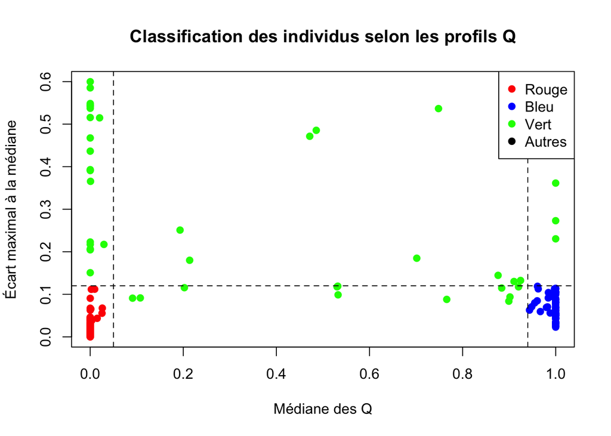

```r
plot(
  resultats$Mediane,
  resultats$Ecart_max,
  col = couleurs,
  pch = 19,
  xlab = "Médiane des Q",
  ylab = "Écart maximal à la médiane",
  main = "Classification des individus selon les profils Q",
  xlim = c(0, 1)
)

abline(v = 0.05, lty = 2)
abline(v = 0.94, lty = 2)
abline(h = 0.12, lty = 2)

legend("topright",
       legend = c("Rouge", "Bleu", "Vert", "Autres"),
       col = c("red", "blue", "green", "black"),
       pch = 19)
```

## Nombre d’individus dans chaque groupe

```r
table(resultats$Groupe)
```

```
##
##  Bleu Rouge  Vert
##    57    76    42
```

## Liste des individus par groupe

```r
split(
  resultats$Individu,
  resultats$Groupe
)
```

```
## $Bleu
##  [1] "14Ain1001Cn" "14Ain1002Cn" "14Ain1036Cn" "14Ain1037Cn" "14Avi1001Cn"
##  [6] "14Avi1002Cn" "14Avi1003Cn" "14Avi1004Cn" "14Avi1005Cn" "14Avi1006Cn"
## [11] "14Avi1007Cn" "14Avi1008Cn" "14Avi1036Cn" "14Avi1037Cn" "14Avi1038Cn"
## [16] "14Bue1003Cn" "14Bue1004Cn" "14Bue1005Cn" "14Bue1007Cn" "14Bue1008Cn"
## [21] "15Avi1003Cn" "15Avi1004Cn" "15Avi1005Cn" "15Avi1006Cn" "15Avi1007Cn"
## [26] "15Avi1008Cn" "15Avi1009Cn" "15Avi1010Cn" "15Bue1001Cn" "15Bue1017Cn"
## [31] "15Bue1002Cn" "15Bue1003Cn" "15Caa1001Cn" "15Caa1002Cn" "15Caa1003Cn"
## [36] "15Caa1004Cn" "15Caa1005Cn" "15Caa1007Cn" "15Caa1009Cn" "15Caa1010Cn"
## [41] "15Cab1001Cn" "15Cab1002Cn" "15Cab1003Cn" "15Cab1004Cn" "15Cab1005Cn"
## [46] "15Cab1006Cn" "15Cab1007Cn" "15Cab1008Cn" "15Jus1013Cn" "15Jus1014Cn"
## [51] "15Jus1010Cn" "15Jus1011Cn" "15Jus1012Cn" "15Jus1015Cn" "15Jus1017Cn"
## [56] "15Jus1018Cn" "15Jus1019Cn"
##
## $Rouge
```

[output cut: 27 more lines]

# 7. Nombre de chromosomes introgressés

Pour les individus présentant une médiane inférieure à 0.05, on compte les chromosomes dont la Q-value est supérieure à 0.12.

Pour les individus présentant une médiane supérieure à 0.94, on compte les chromosomes dont la Q-value est inférieure à 0.88.

```r
Nb_chr_introgresses <- apply(
  mat,
  1,
  function(x) {

    med <- median(
      x,
      na.rm = TRUE
    )

    if (med < 0.05) {

      sum(
        x > 0.12,
        na.rm = TRUE
      )

    } else if (med > 0.94) {

      sum(
        x < 0.88,
        na.rm = TRUE
      )

    } else {

      NA
    }
  }
)

Nb_chr_introgresses
```

```
## 14Ain1001Cn 14Ain1002Cn 14Ain1012Pt 14Ain1013Pt 14Ain1014Pt 14Ain1036Cn
##           0           0           0           0           0           0
## 14Ain1042Pt 14Ain1043Pt 14Ain1011Pt 14Ain1037Cn 14Ain1038Pt 14Ain1039Pt
##           0           0           0           0           0           0
## 14Ain1040Pt 14Ain1041Pt 14Avi1001Cn 14Avi1002Cn 14Avi1003Cn 14Avi1004Cn
##           0           0           0           0           0           0
## 14Avi1005Cn 14Avi1006Cn 14Avi1007Cn 14Avi1008Cn 14Avi1036Cn 14Avi1037Cn
##           0           0           0           0           0           0
## 14Avi1038Cn 14Bue1003Cn 14Bue1004Cn 14Bue1005Cn 14Bue1006Hy 14Bue1013Pt
##           0           0           0           0          NA           0
## 14Bue1014Pt 14Bue1015Pt 14Bue1016Hy 14Bue1017Pt 14Bue1007Cn 14Bue1008Cn
##           0           0           1           0           0           0
## 14Bue1011Pt 14Bue1012Pt 14Bue1018Pt 14Bue1019Pt 14Man1001Pt 14Man1012Pt
##           0           0           0           0           0           0
## 14Man1013Pt 14Man1014Pt 14Man1015Pt 14Man1016Pt 14Man1021Hy 14Man1022Pt
##           0           0           0           0          NA           0
## 14Man1002Hy 14Man1010Hy 14Man1011Hy 14Man1017Pt 14Man1018Pt 14Man1019Pt
##           1           1           1           0           0           0
## 14Man1020Hy 14Per1013Pt 14Per1014Pt 14Per2011Pt 14Per2012Pt 14Per2013Hy
##           1           0           0           0           0          NA
## 14Per1011Pt 14Per1012Pt 14Per2014Pt 14Per2015Pt 15Avi1003Cn 15Avi1004Cn
##           0           0           0           0           0           0
## 15Avi1005Cn 15Avi1006Cn 15Avi1007Cn 15Avi1012Hy 15Avi1001Hy 15Avi1002Hy
##           0           0           0           1           2          NA
## 15Avi1008Cn 15Avi1009Cn 15Avi1010Cn 15Avi1011Hy 15Avi1013Hy 15Bau1005Pt
##           0           0           0           1          NA           0
## 15Bau1006Hy 15Bau1008Pt 15Bau1009Pt 15Bau1013Pt 15Bau1014Pt 15Bau1015Pt
##          NA           0           0           0           0           0
## 15Bau1016Hy 15Bau1017Pt 15Bau1018Pt 15Bau1022Pt 15Bau1023Pt 15Bau1024Pt
##           6           0           0           0           0           0
## 15Bau1025Pt 15Bau1001Pt 15Bau1002Pt 15Bau1003Pt 15Bau1004Hy 15Bau1007Pt
##           0           0           0           0           1           0
## 15Bau1010Hy 15Bau1011Pt 15Bau1012Pt 15Bau1019Hy 15Bau1020Hy 15Bau1021Hy
##           2           0           0           1           1           2
## 15Bue1001Cn 15Bue1005Hy 15Bue1006Pt 15Bue1007Hy 15Bue1008Pt 15Bue1009Hy
##           0          NA           1          NA           0          NA
## 15Bue1010Hy 15Bue1011Hy 15Bue1012Hy 15Bue1013Pt 15Bue1015Pt 15Bue1016Hy
##          NA          NA           2           0           0          NA
## 15Bue1017Cn 15Bue1018Hy 15Bue1002Cn 15Bue1003Cn 15Bue1004Pt 15Caa1001Cn
##           0          NA           0           0           0           0
## 15Caa1002Cn 15Caa1003Cn 15Caa1004Cn 15Caa1005Cn 15Caa1006Hy 15Caa1007Cn
##           0           0           0           0          NA           0
## 15Caa1008Hy 15Caa1009Cn 15Caa1010Cn 15Caa1011Pt 15Caa1012Pt 15Caa1013Pt
##          NA           0           0           0           0           0
## 15Caa1014Pt 15Caa1015Hy 15Caa1016Hy 15Caa1017Hy 15Caa1018Pt 15Caa1020Pt
##           0          NA           1          NA           0           0
## 15Caa1019Hy 15Cab1001Cn 15Cab1002Cn 15Cab1003Cn 15Cab1004Cn 15Cab1005Cn
##           1           0           2           0           0           0
## 15Cab1006Cn 15Cab1007Cn 15Cab1008Cn 15Cab1009Hy 15Cab1012Pt 15Cab1013Pt
##           1           0           0          NA           0           0
## 15Cab1014Pt 15Cab1015Pt 15Cab1016Pt 15Cab1017Pt 15Cab1018Pt 15Cab1019Pt
##           0           0           0           0           0           0
## 15Cab1010Hy 15Jus1004Hy 15Jus1005Hy 15Jus1013Cn 15Jus1014Cn 15Jus1001Pt
##          NA           1           1           1           1           0
## 15Jus1002Hy 15Jus1003Hy 15Jus1006Pt 15Jus1007Pt 15Jus1009Hy 15Jus1010Cn
##           1           1           0           0          NA           0
## 15Jus1011Cn 15Jus1012Cn 15Jus1015Cn 15Jus1016Hy 15Jus1017Cn 15Jus1018Cn
##           3           0           0           1           0           0
## 15Jus1019Cn
##           0
```

# 8. L’acp ne detecte pas les individus fortement introgressés des purs

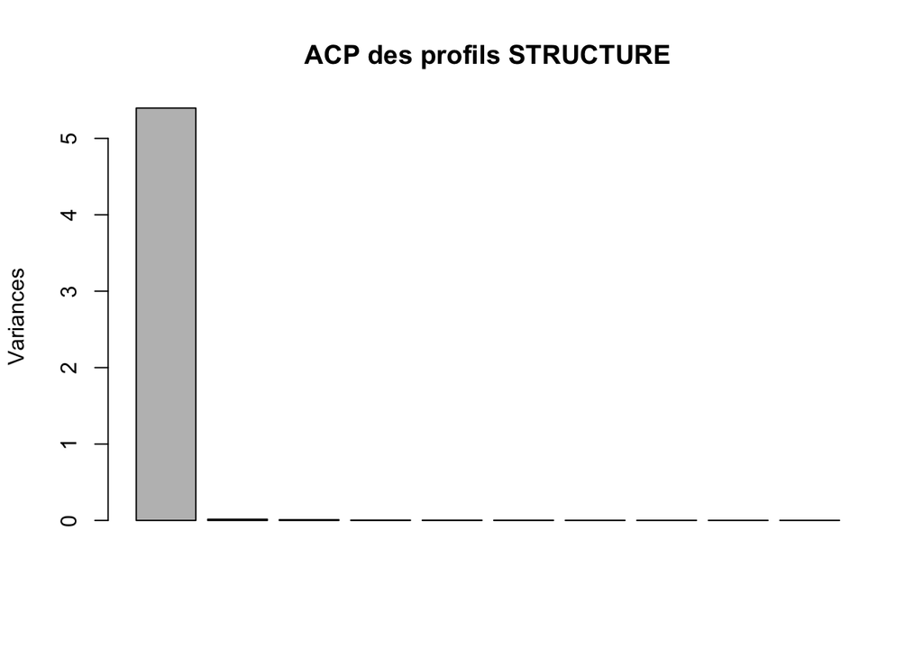

```r
acp <- prcomp(mat, scale. = FALSE)

plot(acp,
     main = "ACP des profils STRUCTURE")
```

```r
summary(acp)
```

```
## Importance of components:
##                           PC1     PC2     PC3     PC4     PC5     PC6     PC7
## Standard deviation     2.3231 0.12446 0.09633 0.06465 0.05732 0.05268 0.04243
## Proportion of Variance 0.9911 0.00284 0.00170 0.00077 0.00060 0.00051 0.00033
## Cumulative Proportion  0.9911 0.99396 0.99566 0.99643 0.99703 0.99754 0.99787
##                            PC8     PC9    PC10    PC11    PC12    PC13    PC14
## Standard deviation     0.03918 0.03582 0.03531 0.03106 0.03027 0.02930 0.02796
## Proportion of Variance 0.00028 0.00024 0.00023 0.00018 0.00017 0.00016 0.00014
## Cumulative Proportion  0.99815 0.99839 0.99862 0.99880 0.99896 0.99912 0.99926
##                           PC15    PC16    PC17    PC18    PC19    PC20    PC21
## Standard deviation     0.02537 0.02471 0.02333 0.02141 0.01889 0.01706 0.01653
## Proportion of Variance 0.00012 0.00011 0.00010 0.00008 0.00007 0.00005 0.00005
## Cumulative Proportion  0.99938 0.99950 0.99960 0.99968 0.99974 0.99980 0.99985
##                           PC22    PC23    PC24    PC25
## Standard deviation     0.01607 0.01471 0.01403 0.01238
## Proportion of Variance 0.00005 0.00004 0.00004 0.00003
## Cumulative Proportion  0.99990 0.99994 0.99997 1.00000
```

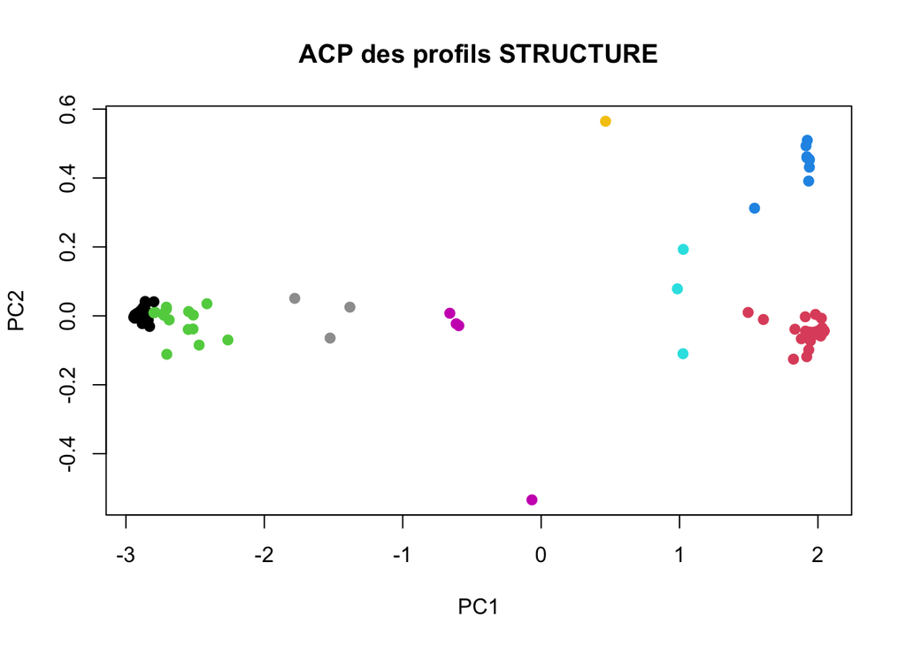

```r
groups <- cutree(hc, k = 8)

plot(acp$x[,1], acp$x[,2],
     col = groups,
     pch = 19,
     xlab = "PC1",
     ylab = "PC2",
     main = "ACP des profils STRUCTURE")
```

# Visualisons les differents groupes

```r
split(data$Individu, groups)
```

```
## $`1`
##  [1] "14Ain1001Cn" "14Ain1002Cn" "14Ain1037Cn" "14Avi1001Cn" "14Avi1002Cn"
##  [6] "14Avi1003Cn" "14Avi1004Cn" "14Avi1005Cn" "14Avi1006Cn" "14Avi1007Cn"
## [11] "14Avi1008Cn" "14Avi1036Cn" "14Avi1037Cn" "14Avi1038Cn" "14Bue1003Cn"
## [16] "14Bue1004Cn" "14Bue1005Cn" "14Bue1007Cn" "14Bue1008Cn" "15Avi1003Cn"
## [21] "15Avi1004Cn" "15Avi1005Cn" "15Avi1006Cn" "15Avi1007Cn" "15Avi1001Hy"
## [26] "15Avi1008Cn" "15Avi1009Cn" "15Avi1010Cn" "15Avi1011Hy" "15Bue1001Cn"
## [31] "15Bue1017Cn" "15Bue1002Cn" "15Bue1003Cn" "15Caa1003Cn" "15Caa1004Cn"
## [36] "15Caa1005Cn" "15Caa1007Cn" "15Caa1009Cn" "15Caa1010Cn" "15Cab1001Cn"
## [41] "15Cab1003Cn" "15Cab1004Cn" "15Cab1005Cn" "15Cab1007Cn" "15Cab1008Cn"
## [46] "15Jus1010Cn" "15Jus1012Cn" "15Jus1015Cn" "15Jus1016Hy" "15Jus1017Cn"
## [51] "15Jus1018Cn" "15Jus1019Cn"
##
## $`2`
##  [1] "14Ain1012Pt" "14Ain1013Pt" "14Ain1014Pt" "14Ain1042Pt" "14Ain1043Pt"
```

[output cut: 38 more lines]

# Par exemple le groupe 3 est constitue de purs et d’hybrides, pourquoi ?

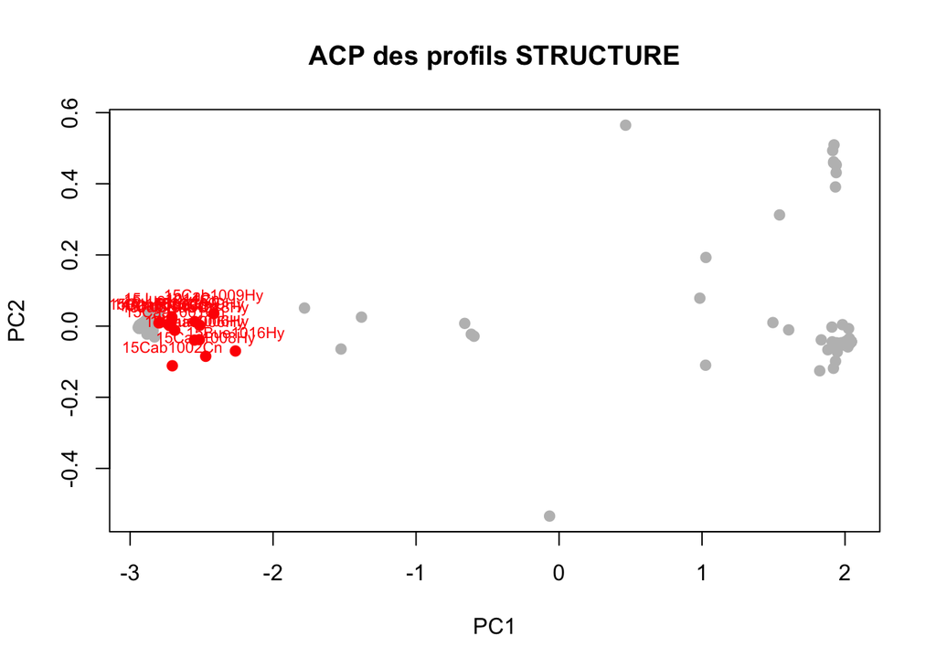

```r
couleurs <- rep("grey", nrow(acp$x))
couleurs[groups == 3] <- "red"

plot(acp$x[,1], acp$x[,2],
     col = couleurs,
     pch = 19,
     xlab = "PC1",
     ylab = "PC2",
     main = "ACP des profils STRUCTURE")

text(acp$x[groups == 3, 1],
     acp$x[groups == 3, 2],
     labels = data$Individu[groups == 3],
     col = "red",
     pos = 3,
     cex = 0.7)
```

```r
split(data$Individu, groups)
```

```
## $`1`
##  [1] "14Ain1001Cn" "14Ain1002Cn" "14Ain1037Cn" "14Avi1001Cn" "14Avi1002Cn"
##  [6] "14Avi1003Cn" "14Avi1004Cn" "14Avi1005Cn" "14Avi1006Cn" "14Avi1007Cn"
## [11] "14Avi1008Cn" "14Avi1036Cn" "14Avi1037Cn" "14Avi1038Cn" "14Bue1003Cn"
## [16] "14Bue1004Cn" "14Bue1005Cn" "14Bue1007Cn" "14Bue1008Cn" "15Avi1003Cn"
## [21] "15Avi1004Cn" "15Avi1005Cn" "15Avi1006Cn" "15Avi1007Cn" "15Avi1001Hy"
## [26] "15Avi1008Cn" "15Avi1009Cn" "15Avi1010Cn" "15Avi1011Hy" "15Bue1001Cn"
## [31] "15Bue1017Cn" "15Bue1002Cn" "15Bue1003Cn" "15Caa1003Cn" "15Caa1004Cn"
## [36] "15Caa1005Cn" "15Caa1007Cn" "15Caa1009Cn" "15Caa1010Cn" "15Cab1001Cn"
## [41] "15Cab1003Cn" "15Cab1004Cn" "15Cab1005Cn" "15Cab1007Cn" "15Cab1008Cn"
## [46] "15Jus1010Cn" "15Jus1012Cn" "15Jus1015Cn" "15Jus1016Hy" "15Jus1017Cn"
## [51] "15Jus1018Cn" "15Jus1019Cn"
##
## $`2`
##  [1] "14Ain1012Pt" "14Ain1013Pt" "14Ain1014Pt" "14Ain1042Pt" "14Ain1043Pt"
```

[output cut: 38 more lines]